# Task 2.1 R语言的基础练习

任务一： 读取数据，并命名为dat0。利用summary函数观察各个变量的主要描述统计量。其中数据第一列表示行政区，第二列代表房子面积，第三列代表是否是学区房，第四列为单价，剩余两列为经纬度。请用三五句文字描述一下你所能观察到的现象。

```
##           CATE           AREA              school          price
##  chaoyang   :2915   Min.   :    7.80   Min.   :0.000   Min.   :  5496
##  dongcheng  :2944   1st Qu.:   59.94   1st Qu.:0.000   1st Qu.: 42701
##  fengtai    :3003   Median :   78.70   Median :0.000   Median : 57523
##  haidian    :3001   Mean   :   95.81   Mean   :0.301   Mean   : 61266
##  shijingshan:2040   3rd Qu.:  112.08   3rd Qu.:1.000   3rd Qu.: 76336
##  xicheng    :2892   Max.   :18779.50   Max.   :1.000   Max.   :206667
##       LONG            LAT
##  Min.   :106.0   Min.   :22.34
##  1st Qu.:116.3   1st Qu.:39.89
##  Median :116.4   Median :39.92
##  Mean   :116.4   Mean   :39.89
##  3rd Qu.:116.4   3rd Qu.:39.96
##  Max.   :123.9   Max.   :41.84
```

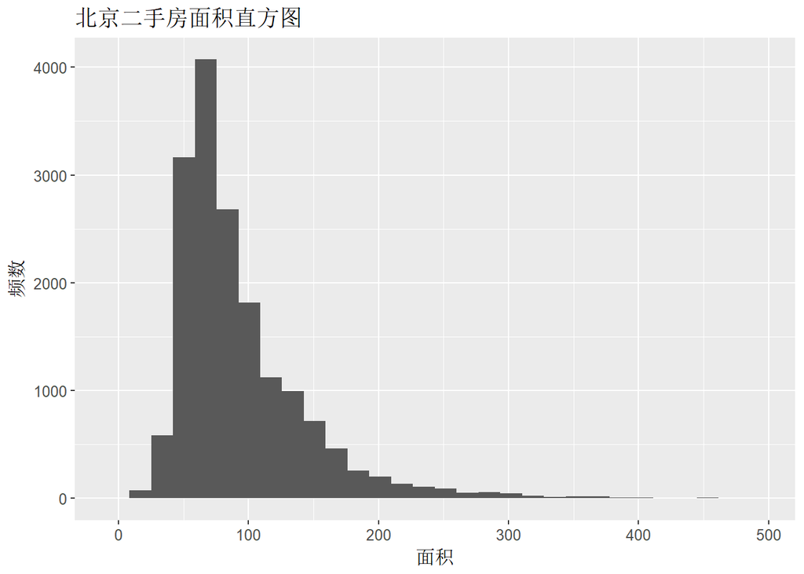

任务三：按照西城，东城，海淀，朝阳，丰台，石景山的顺序，输出单价对不同城区，是否为学区房的箱线图，并给出描述分析。

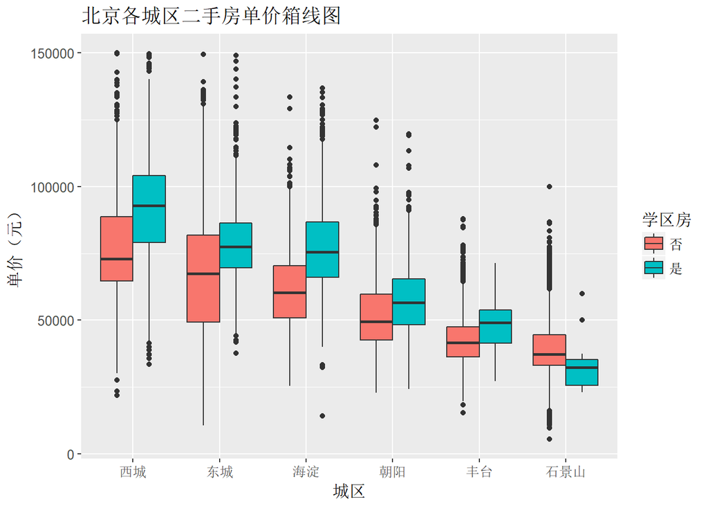

任务四：在R中获取北京市地图，并在地图上绘制出二手房的位置，学区房和非学区房用不同颜色表示（提示：可能用到的程序包 ggplot2, ggmap, baidumap）。给出简单的描述。

[figure not shown]

任务五：在地图上展示出二手房的价格，高价为红色，低价为绿色（提示：热力图或瓦片图）。同样，给出你的简单描述。

[figure not shown]